# Final Project — NYC Data Analysis

Author

Pere Caparrós

# Emergencies registered in New York City

## Introduction

In this project we will explore the amount of incidents that concerns to OEM (Office of Emergency Managment) registered since August 2016. We will try to see where OEM can act faster to solve citizen problems.

First of all, we need to open some libraries to manipulate and visualize the data.

#### Loading necessary libraries

```r
library(dplyr)
library(tidyverse)
library(ggplot2)
library(stringr)
library(lubridate)
library(forcats)
```

#### Loading the dataset

We introduce the data from **NYC Open Data** *(https://data.cityofnewyork.us/Public-Safety/Emergency-Response-Incidents/pasr-j7fb/about_data)*

```r
emergencies = read.csv('https://data.cityofnewyork.us/resource/pasr-j7fb.csv?$limit=50000')
```

## Cleaning Data

Next step will be focused on cleaning the data we have taken from NYC open Data. We first use an *str_trim()* to modify the ‘incident_type’ values to clean and organised values, so we can reorder them in next steps.

```r
emergencies %>%
  mutate(incident_type = str_trim(incident_type)) %>%
  head(10)
```

```
                            incident_type                      location
1                      Utility-Water Main              136-17 72 Avenue
2            Structural-Sidewalk Collapse                  927 Broadway
3                           Utility-Other
4                    Administration-Other Seagirt Blvd & Beach 9 Street
5                   Law Enforcement-Other
6                      Utility-Water Main                2-17 54 Avenue
7                          Fire-2nd Alarm            238 East 24 Street
8                      Utility-Water Main   7th Avenue & West 27 Street
9  Fire-10-76 (Commercial High Rise Fire)            130 East 57 Street
10                       Structural-Crane
     borough           creation_date closed_date latitude longitude
1     Queens 2017-01-16T13:13:38.000             40.71400 -73.82999
2  Manhattan 2016-10-29T12:13:31.000             40.71442 -74.00608
3  Manhattan 2016-11-22T08:53:17.000                   NA        NA
4     Queens 2016-11-14T15:53:54.000             40.71400 -73.82999
5   Brooklyn 2016-10-29T17:35:28.000                   NA        NA
6     Queens 2016-12-02T16:40:13.000             40.71400 -73.82999
7  Manhattan 2016-11-25T04:06:09.000             40.71442 -74.00608
8  Manhattan 2016-12-03T04:17:30.000             40.71442 -74.00608
9  Manhattan 2016-11-26T05:45:43.000                   NA        NA
10  Brooklyn 2016-11-18T13:12:51.000                   NA        NA
```

Below we can see how we change the column ‘creation_date’ to two columns called ‘date’ and ‘time.’ In the ‘date’ one, we have the year-month-day. In the ‘time’ column, we have the time in hours:minutes. We did this in order to have a more clear structure for the date and the exact minute each event happened.

```r
emergencies = emergencies %>%
  rename('creat_date' = 'creation_date',
         'close_date' = 'closed_date') %>%
  mutate(
    creat_date = ymd_hms(creat_date),
    creat_date = floor_date(creat_date, unit = 'minute'),
    creation_date = as.Date(creat_date),
    creation_time = format(creat_date, format = '%H:%M'),
    close_date = ydm_hms(close_date),
    close_date = floor_date(close_date, unit = 'minute'),
    closed_date = as.Date(close_date),
    closed_time = format(close_date, format = '%H:%M')
  )
head(emergencies, 10)
```

```
                            incident_type                      location
1                      Utility-Water Main              136-17 72 Avenue
2            Structural-Sidewalk Collapse                  927 Broadway
3                           Utility-Other
4                    Administration-Other Seagirt Blvd & Beach 9 Street
5                   Law Enforcement-Other
6                      Utility-Water Main                2-17 54 Avenue
7                          Fire-2nd Alarm            238 East 24 Street
8                      Utility-Water Main   7th Avenue & West 27 Street
9  Fire-10-76 (Commercial High Rise Fire)            130 East 57 Street
10                       Structural-Crane
     borough          creat_date close_date latitude longitude creation_date
1     Queens 2017-01-16 13:13:00       <NA> 40.71400 -73.82999    2017-01-16
2  Manhattan 2016-10-29 12:13:00       <NA> 40.71442 -74.00608    2016-10-29
3  Manhattan 2016-11-22 08:53:00       <NA>       NA        NA    2016-11-22
```

[output cut: 18 more lines]

```r
emergencies_small = emergencies %>%
  select(-creat_date, -close_date)

head(emergencies_small)
```

```
                 incident_type                      location   borough latitude
1           Utility-Water Main              136-17 72 Avenue    Queens 40.71400
2 Structural-Sidewalk Collapse                  927 Broadway Manhattan 40.71442
3                Utility-Other                               Manhattan       NA
4         Administration-Other Seagirt Blvd & Beach 9 Street    Queens 40.71400
5        Law Enforcement-Other                                Brooklyn       NA
6           Utility-Water Main                2-17 54 Avenue    Queens 40.71400
  longitude creation_date creation_time closed_date closed_time
1 -73.82999    2017-01-16         13:13        <NA>        <NA>
2 -74.00608    2016-10-29         12:13        <NA>        <NA>
3        NA    2016-11-22         08:53        <NA>        <NA>
4 -73.82999    2016-11-14         15:53        <NA>        <NA>
5        NA    2016-10-29         17:35        <NA>        <NA>
6 -73.82999    2016-12-02         16:40        <NA>        <NA>
```

## How are the incidences distributed by New York City boroughs?

We will answer this question with the aid of the code written below.

```r
emergency_by_borough = emergencies_small %>%
  group_by(borough) %>%
  summarise(
    Number_of_incidents = n()
  )

head(emergency_by_borough)
```

```
# A tibble: 6 × 2
  borough Number_of_incidents
  <chr>                 <int>
1 Astoria                   2
2 BRONX                     1
3 BRonx                     1
4 Bergen                    1
5 BrONX                     1
6 Brinx                     1
```

```r
emergencies_small = emergencies_small %>%
  mutate(borough = case_when(
    str_detect(str_to_lower(borough), "brooklyn") ~ "Brooklyn",
    str_detect(str_to_lower(borough), "manhattan") ~ "Manhattan",
    str_detect(str_to_lower(borough), "queens") ~ "Queens",
    str_detect(str_to_lower(borough), "bronx") ~ "Bronx",
    str_detect(str_to_lower(borough), "staten") ~ "Staten Island",
    TRUE ~ NA_character_
  ))
```

After these few lines of code, we have cleaned the data and inserted correctly into the 5 boroughs. However, we have some NA values that we have not been able to insert them into any borough.

```r
emergency_by_borough = emergencies_small %>%
  group_by(borough) %>%
  summarise(
    Number_of_incidents = n()
  )
emergencies_clean = emergency_by_borough[complete.cases(emergency_by_borough),]
head(emergencies_clean)
```

```
# A tibble: 5 × 2
  borough       Number_of_incidents
  <chr>                       <int>
1 Bronx                        1622
2 Brooklyn                     3446
3 Manhattan                    3662
4 Queens                       2056
5 Staten Island                 583
```

Finally, we have this table showing the number of incidences in each New York City borough.

#### Plot 1: How many incidents have occurred in each borough of New York City?

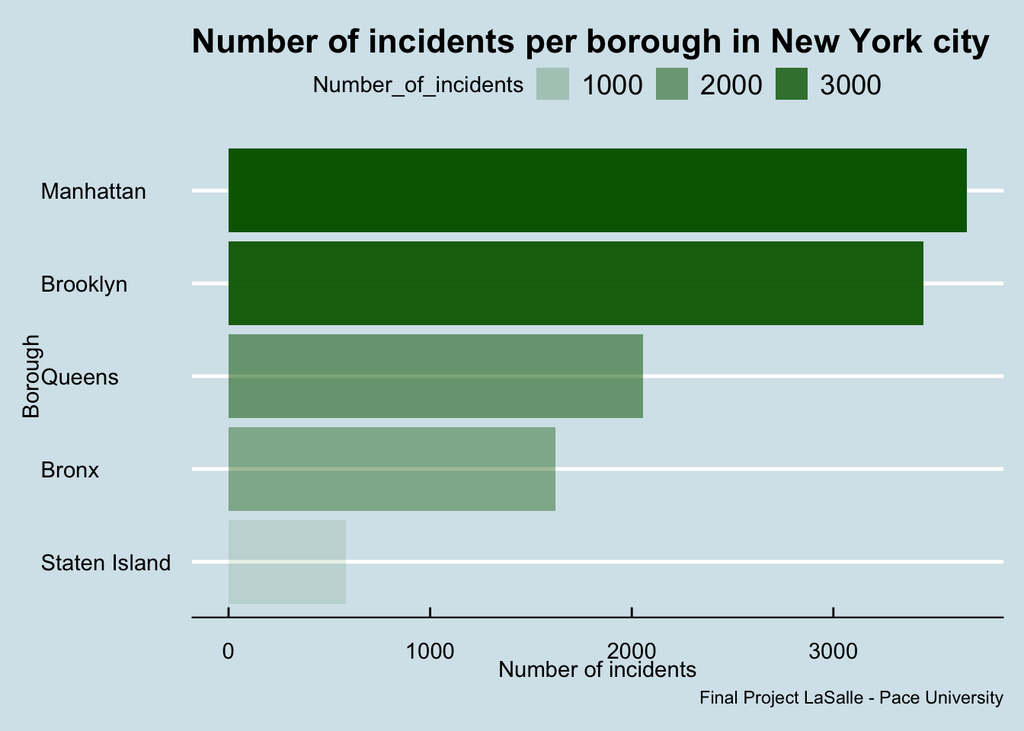

```r
library(ggthemes)


ggplot(emergencies_clean, aes(x = reorder(borough, Number_of_incidents), y = Number_of_incidents, alpha = Number_of_incidents)) +
  geom_col(fill = 'darkgreen') +
  coord_flip() +
  theme_economist() +
  labs(x = 'Borough', y = 'Number of incidents', title = 'Number of incidents per borough in New York city', caption = 'Final Project LaSalle - Pace University')
```

We can see that the districts of Manhattan and Brooklyn are the ones with the highest number of incidences recorded since August 2016. For this reason, we decide to do a deeper research in these two boroughs; searching which is the main incidence type and the most frequent hours and months where occurs.

## Investigation of the main causes of incidences in Manhattan and Brooklyn

#### Manhattan

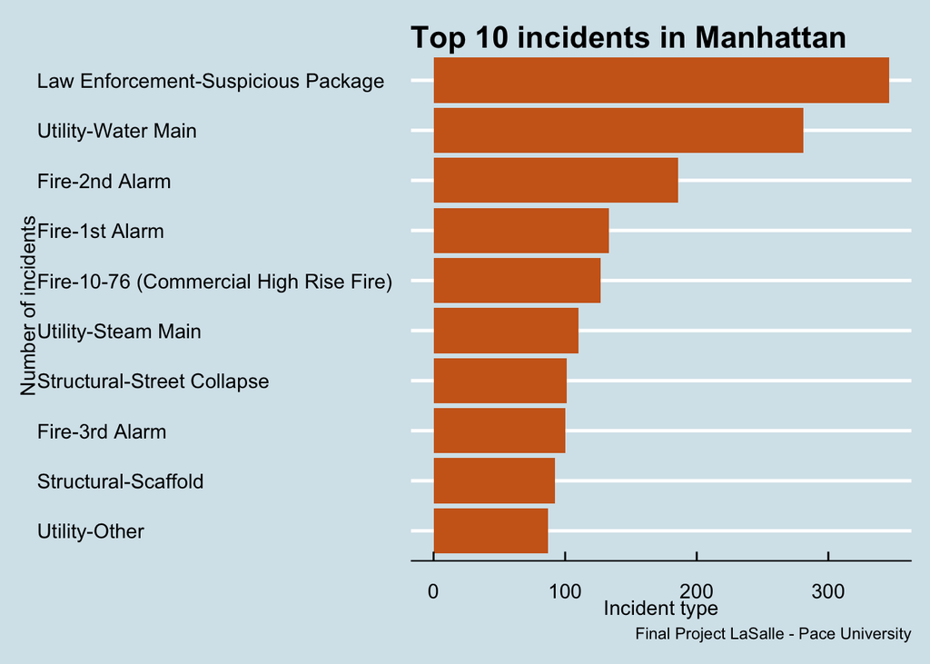

```r
emergencies_manhattan = emergencies_small %>%
  filter(
    borough == 'Manhattan'
  )

emergency_type = emergencies_manhattan %>%
   mutate(
    incident_type = ifelse(incident_type == 'LawEnforcement-Suspicious Package', 'Law Enforcement-Suspicious Package', incident_type)
  ) %>%
  group_by(incident_type) %>%
  summarise(
    Number_of_incidents = n()
  ) %>%
   mutate(
    Rank = rank(-Number_of_incidents)  # or: rank(desc(Number_of_incidents))
  ) %>%
  arrange(Rank) %>%
  filter(
    Rank <= 10
  )


ggplot(emergency_type, aes(x = reorder(incident_type, Number_of_incidents), y = Number_of_incidents)) +
  geom_col(fill = 'chocolate3') +
  coord_flip() +
  labs() +
  labs(x = 'Number of incidents', y = 'Incident type', title = 'Top 10 incidents in Manhattan', caption = 'Final Project LaSalle - Pace University') +
  theme_economist()
```

In this barchart is shown an elevated number of water main issues.

#### Brooklyn

```r
emergencies_brooklyn = emergencies_small %>%
  filter(
    borough == 'Brooklyn'
  )

emergency_type_2 = emergencies_brooklyn %>%
  group_by(incident_type) %>%
  summarise(
    Number_of_incidents = n()
  ) %>%
   mutate(
    Rank = rank(-Number_of_incidents)  # or: rank(desc(Number_of_incidents))
  ) %>%
  arrange(Rank) %>%
  filter(
    Rank <= 10
  )


head(emergency_type_2)
```

```
# A tibble: 6 × 3
  incident_type        Number_of_incidents  Rank
  <chr>                              <int> <dbl>
1 Fire-2nd Alarm                       423     1
2 Fire-3rd Alarm                       181     2
3 Utility-Water Main                   171     3
4 Utility-Power Outage                 162     4
5 Fire-1st Alarm                       140     5
6 Structural-Collapse                  119     6
```

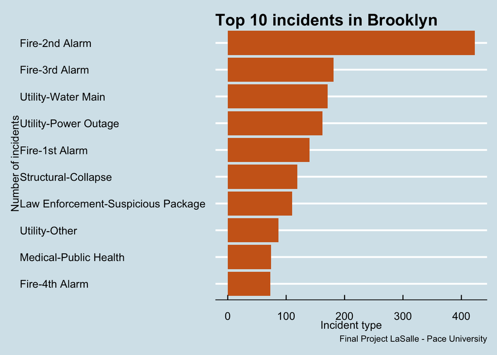

```r
ggplot(emergency_type_2, aes(x = reorder(incident_type, Number_of_incidents), y = Number_of_incidents)) +
  geom_col(fill = 'chocolate3') +
  coord_flip() +
  labs() +
  labs(x = 'Number of incidents', y = 'Incident type', title = 'Top 10 incidents in Brooklyn', caption = 'Final Project LaSalle - Pace University') +
  theme_economist()
```

Fire alarms are, by far, the type of incidents that have been more common in the Brooklyn district since August 2016.

## Which are the hours with most number of incidences in Manhattan and Brooklyn?

#### Manhattan

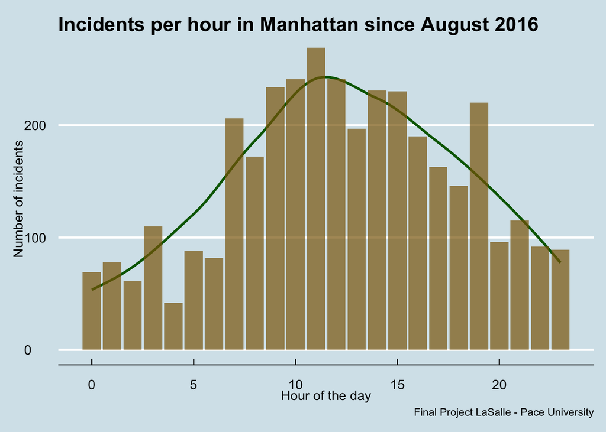

```r
incidents_per_hour_manhattan = emergencies_manhattan %>%
  mutate(
    hour = hour(hm(creation_time))
    )


incidents_per_hour_count_manhattan = incidents_per_hour_manhattan %>%
  group_by(hour) %>%
  summarise(
    Number_of_incidents = n()
  )

ggplot(incidents_per_hour_count_manhattan, aes(x = hour, Number_of_incidents)) +
  geom_smooth(color = 'darkgreen', se = F) +
  geom_col(fill = 'darkgoldenrod4', alpha = 0.7) +
  theme_economist() +
  labs(x = 'Hour of the day', y = 'Number of incidents', title = 'Incidents per hour in Manhattan since August 2016', caption = 'Final Project LaSalle - Pace University')
```

We can observe that the hours with most incidence in Manhattan are between 9 am and 5 pm.

#### Brooklyn

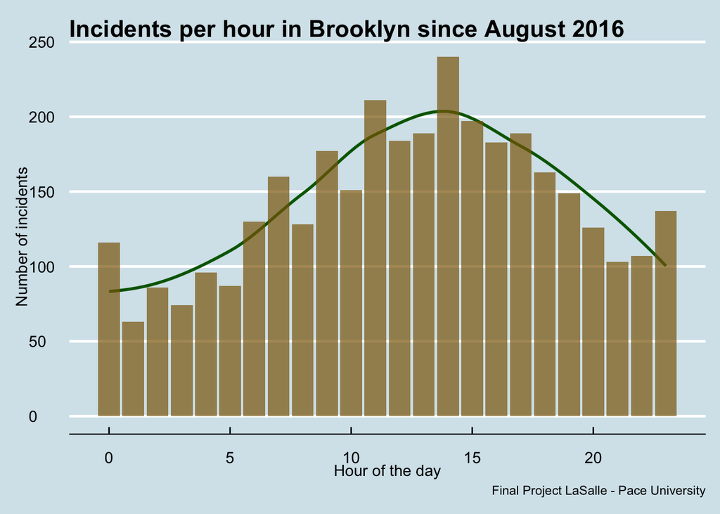

```r
incidents_per_hour_brooklyn = emergencies_brooklyn %>%
  mutate(
    hour = hour(hm(creation_time))
    )


incidents_per_hour_count_brooklyn = incidents_per_hour_brooklyn %>%
  group_by(hour) %>%
  summarise(
    Number_of_incidents = n()
  )

ggplot(incidents_per_hour_count_brooklyn, aes(x = hour, Number_of_incidents)) +
  geom_smooth(color = 'darkgreen', se = F) +
  geom_col(fill = 'darkgoldenrod4', alpha = 0.7) +
  theme_economist() +
  labs(x = 'Hour of the day', y = 'Number of incidents', title = 'Incidents per hour in Brooklyn since August 2016', caption = 'Final Project LaSalle - Pace University')
```

## Which are the months in the day that have the most number of incidents in Manhattan and Brooklyn?

#### Manhattan

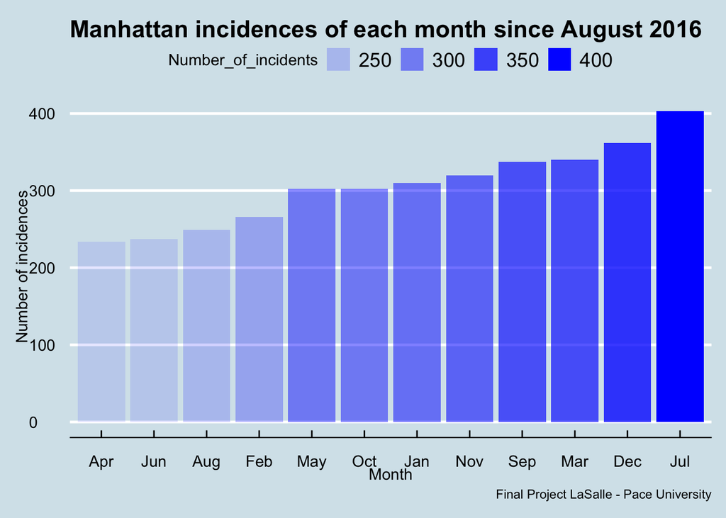

```r
Incidences_per_month_manhattan = emergencies_manhattan %>%
  mutate(
    month = month(creation_date, label = T)
  ) %>%
  group_by(month) %>%
  summarise(
    Number_of_incidents = n()
  )

ggplot(Incidences_per_month_manhattan, aes(x = reorder(month, Number_of_incidents), y = Number_of_incidents, alpha = Number_of_incidents)) +
  geom_col(fill = 'blue') +
  labs(x = 'Month', y = 'Number of incidences', title = 'Manhattan incidences of each month since August 2016', caption = 'Final Project LaSalle - Pace University') +
  theme_economist()
```

In Manhattan the most incident month is July. We would need to do a deep research to know exactly the reasons why July has the highest number of incidences but could be caused by the high volume of tourism in months of December and July.

#### Brooklyn

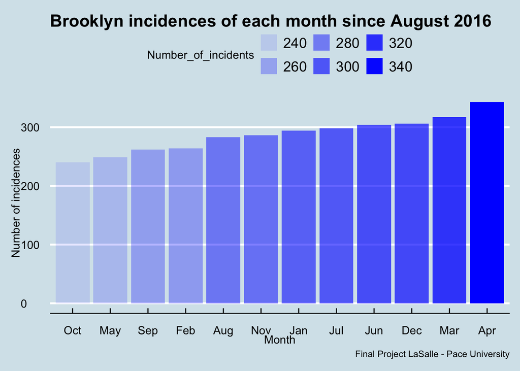

```r
Incidences_per_month_brooklyn = emergencies_brooklyn %>%
  mutate(
    month = month(creation_date, label = T)
  ) %>%
  group_by(month) %>%
  summarise(
    Number_of_incidents = n()
  )

ggplot(Incidences_per_month_brooklyn, aes(x = reorder(month, Number_of_incidents), y = Number_of_incidents, alpha = Number_of_incidents)) +
  geom_col(fill = 'blue') +
  labs(x = 'Month', y = 'Number of incidences', title = 'Brooklyn incidences of each month since August 2016', caption = 'Final Project LaSalle - Pace University') +
  theme_economist()
```

Talking about Brooklyn, we see that in March and April the incidences increase. However, the month with less incidences is October. Could be caused by the increasing temperature or by the increasing tourism in that part of the city. However, we would need to research more in deep to find the correct causes of this increase.